# Part I - (LOAN DATASET PRESENTATION)

## Introduction

> The general objective of this project is to present visualizations to show the relationship between features as provided in the Prosper loan dataset such as BorrowerRate, loan Term, BorrowerAPR,loan Status, ProsperRating(Alpha, occupation and many more.

## Dataset Overview

> The Loan dataset provided by Prosper is used for the presentation, it contains both quantitative and qualitative features. This data set contains 113,937 rows of loans with 81 columns for variables on each loan, including loan amount, borrower rate, current loan status, borrower income, Prosper score, loan term and many more.

## Preliminary Wrangling

```python
# import all packages and set plots to be embedded inline
import numpy as np
import pandas as pd
import matplotlib.pyplot as plt
import seaborn as sb

%matplotlib inline
```

> Loading the dataset and describing its properties

```python
data_loan=pd.read_csv('prosperLoanData.csv')
data_loan.head()
```

|  | ListingKey | ListingNumber | ListingCreationDate | CreditGrade | Term | LoanStatus | ClosedDate | BorrowerAPR | BorrowerRate | LenderYield | ... | LP_ServiceFees | LP_CollectionFees | LP_GrossPrincipalLoss | LP_NetPrincipalLoss | LP_NonPrincipalRecoverypayments | PercentFunded | Recommendations | InvestmentFromFriendsCount | InvestmentFromFriendsAmount | Investors |
| --- | --- | --- | --- | --- | --- | --- | --- | --- | --- | --- | --- | --- | --- | --- | --- | --- | --- | --- | --- | --- | --- |
| 0 | 1021339766868145413AB3B | 193129 | 2007-08-26 19:09:29.263000000 | C | 36 | Completed | 2009-08-14 00:00:00 | 0.16516 | 0.1580 | 0.1380 | ... | -133.18 | 0.0 | 0.0 | 0.0 | 0.0 | 1.0 | 0 | 0 | 0.0 | 258 |
| 1 | 10273602499503308B223C1 | 1209647 | 2014-02-27 08:28:07.900000000 | NaN | 36 | Current | NaN | 0.12016 | 0.0920 | 0.0820 | ... | 0.00 | 0.0 | 0.0 | 0.0 | 0.0 | 1.0 | 0 | 0 | 0.0 | 1 |
| 2 | 0EE9337825851032864889A | 81716 | 2007-01-05 15:00:47.090000000 | HR | 36 | Completed | 2009-12-17 00:00:00 | 0.28269 | 0.2750 | 0.2400 | ... | -24.20 | 0.0 | 0.0 | 0.0 | 0.0 | 1.0 | 0 | 0 | 0.0 | 41 |
| 3 | 0EF5356002482715299901A | 658116 | 2012-10-22 11:02:35.010000000 | NaN | 36 | Current | NaN | 0.12528 | 0.0974 | 0.0874 | ... | -108.01 | 0.0 | 0.0 | 0.0 | 0.0 | 1.0 | 0 | 0 | 0.0 | 158 |
| 4 | 0F023589499656230C5E3E2 | 909464 | 2013-09-14 18:38:39.097000000 | NaN | 36 | Current | NaN | 0.24614 | 0.2085 | 0.1985 | ... | -60.27 | 0.0 | 0.0 | 0.0 | 0.0 | 1.0 | 0 | 0 | 0.0 | 20 |

5 rows × 81 columns

```python
#Checking the column labels
data_loan.columns
```

```
Index(['ListingKey', 'ListingNumber', 'ListingCreationDate', 'CreditGrade',
       'Term', 'LoanStatus', 'ClosedDate', 'BorrowerAPR', 'BorrowerRate',
       'LenderYield', 'EstimatedEffectiveYield', 'EstimatedLoss',
       'EstimatedReturn', 'ProsperRating (numeric)', 'ProsperRating (Alpha)',
       'ProsperScore', 'ListingCategory (numeric)', 'BorrowerState',
       'Occupation', 'EmploymentStatus', 'EmploymentStatusDuration',
       'IsBorrowerHomeowner', 'CurrentlyInGroup', 'GroupKey',
       'DateCreditPulled', 'CreditScoreRangeLower', 'CreditScoreRangeUpper',
       'FirstRecordedCreditLine', 'CurrentCreditLines', 'OpenCreditLines',
       'TotalCreditLinespast7years', 'OpenRevolvingAccounts',
       'OpenRevolvingMonthlyPayment', 'InquiriesLast6Months', 'TotalInquiries',
       'CurrentDelinquencies', 'AmountDelinquent', 'DelinquenciesLast7Years',
       'PublicRecordsLast10Years', 'PublicRecordsLast12Months',
       'RevolvingCreditBalance', 'BankcardUtilization',
       'AvailableBankcardCredit', 'TotalTrades',
       'TradesNeverDelinquent (percentage)', 'TradesOpenedLast6Months',
       'DebtToIncomeRatio', 'IncomeRange', 'IncomeVerifiable',
       'StatedMonthlyIncome', 'LoanKey', 'TotalProsperLoans',
       'TotalProsperPaymentsBilled', 'OnTimeProsperPayments',
       'ProsperPaymentsLessThanOneMonthLate',
       'ProsperPaymentsOneMonthPlusLate', 'ProsperPrincipalBorrowed',
       'ProsperPrincipalOutstanding', 'ScorexChangeAtTimeOfListing',
       'LoanCurrentDaysDelinquent', 'LoanFirstDefaultedCycleNumber',
       'LoanMonthsSinceOrigination', 'LoanNumber', 'LoanOriginalAmount',
       'LoanOriginationDate', 'LoanOriginationQuarter', 'MemberKey',
       'MonthlyLoanPayment', 'LP_CustomerPayments',
       'LP_CustomerPrincipalPayments', 'LP_InterestandFees', 'LP_ServiceFees',
       'LP_CollectionFees', 'LP_GrossPrincipalLoss', 'LP_NetPrincipalLoss',
       'LP_NonPrincipalRecoverypayments', 'PercentFunded', 'Recommendations',
       'InvestmentFromFriendsCount', 'InvestmentFromFriendsAmount',
       'Investors'],
      dtype='object')
```

```python
# Checking for information on the features
data_loan.info()
```

```
<class 'pandas.core.frame.DataFrame'>
RangeIndex: 113937 entries, 0 to 113936
Data columns (total 81 columns):
ListingKey                             113937 non-null object
ListingNumber                          113937 non-null int64
ListingCreationDate                    113937 non-null object
CreditGrade                            28953 non-null object
Term                                   113937 non-null int64
LoanStatus                             113937 non-null object
ClosedDate                             55089 non-null object
BorrowerAPR                            113912 non-null float64
BorrowerRate                           113937 non-null float64
LenderYield                            113937 non-null float64
EstimatedEffectiveYield                84853 non-null float64
EstimatedLoss                          84853 non-null float64
EstimatedReturn                        84853 non-null float64
ProsperRating (numeric)                84853 non-null float64
ProsperRating (Alpha)                  84853 non-null object
ProsperScore                           84853 non-null float64
ListingCategory (numeric)              113937 non-null int64
BorrowerState                          108422 non-null object
Occupation                             110349 non-null object
EmploymentStatus                       111682 non-null object
EmploymentStatusDuration               106312 non-null float64
IsBorrowerHomeowner                    113937 non-null bool
CurrentlyInGroup                       113937 non-null bool
GroupKey                               13341 non-null object
DateCreditPulled                       113937 non-null object
CreditScoreRangeLower                  113346 non-null float64
CreditScoreRangeUpper                  113346 non-null float64
FirstRecordedCreditLine                113240 non-null object
CurrentCreditLines                     106333 non-null float64
OpenCreditLines                        106333 non-null float64
TotalCreditLinespast7years             113240 non-null float64
OpenRevolvingAccounts                  113937 non-null int64
OpenRevolvingMonthlyPayment            113937 non-null float64
InquiriesLast6Months                   113240 non-null float64
TotalInquiries                         112778 non-null float64
CurrentDelinquencies                   113240 non-null float64
AmountDelinquent                       106315 non-null float64
```

[output cut: 31 more lines]

```
LP_CustomerPayments                    113937 non-null float64
LP_CustomerPrincipalPayments           113937 non-null float64
LP_InterestandFees                     113937 non-null float64
LP_ServiceFees                         113937 non-null float64
LP_CollectionFees                      113937 non-null float64
LP_GrossPrincipalLoss                  113937 non-null float64
LP_NetPrincipalLoss                    113937 non-null float64
LP_NonPrincipalRecoverypayments        113937 non-null float64
PercentFunded                          113937 non-null float64
Recommendations                        113937 non-null int64
InvestmentFromFriendsCount             113937 non-null int64
InvestmentFromFriendsAmount            113937 non-null float64
Investors                              113937 non-null int64
dtypes: bool(3), float64(50), int64(11), object(17)
memory usage: 68.1+ MB
```

```python
# Checking for duplicated rows
data_loan.duplicated().sum()
```

```
0
```

```python
#Checking for missing values.
data_loan.isnull().sum()
```

```
ListingKey                                  0
ListingNumber                               0
ListingCreationDate                         0
CreditGrade                             84984
Term                                        0
LoanStatus                                  0
ClosedDate                              58848
BorrowerAPR                                25
BorrowerRate                                0
LenderYield                                 0
EstimatedEffectiveYield                 29084
EstimatedLoss                           29084
EstimatedReturn                         29084
ProsperRating (numeric)                 29084
ProsperRating (Alpha)                   29084
ProsperScore                            29084
ListingCategory (numeric)                   0
BorrowerState                            5515
Occupation                               3588
EmploymentStatus                         2255
EmploymentStatusDuration                 7625
IsBorrowerHomeowner                         0
CurrentlyInGroup                            0
GroupKey                               100596
DateCreditPulled                            0
CreditScoreRangeLower                     591
CreditScoreRangeUpper                     591
FirstRecordedCreditLine                   697
CurrentCreditLines                       7604
OpenCreditLines                          7604
                                        ...
TotalProsperLoans                       91852
TotalProsperPaymentsBilled              91852
OnTimeProsperPayments                   91852
ProsperPaymentsLessThanOneMonthLate     91852
ProsperPaymentsOneMonthPlusLate         91852
ProsperPrincipalBorrowed                91852
ProsperPrincipalOutstanding             91852
ScorexChangeAtTimeOfListing             95009
LoanCurrentDaysDelinquent                   0
LoanFirstDefaultedCycleNumber           96985
LoanMonthsSinceOrigination                  0
LoanNumber                                  0
LoanOriginalAmount                          0
LoanOriginationDate                         0
LoanOriginationQuarter                      0
MemberKey                                   0
MonthlyLoanPayment                          0
LP_CustomerPayments                         0
LP_CustomerPrincipalPayments                0
LP_InterestandFees                          0
LP_ServiceFees                              0
LP_CollectionFees                           0
LP_GrossPrincipalLoss                       0
LP_NetPrincipalLoss                         0
LP_NonPrincipalRecoverypayments             0
PercentFunded                               0
Recommendations                             0
InvestmentFromFriendsCount                  0
InvestmentFromFriendsAmount                 0
Investors                                   0
Length: 81, dtype: int64
```

```python
# Checking for unique labels in in the occupation feature
data_loan['Occupation'].unique()
```

```
array(['Other', 'Professional', 'Skilled Labor', 'Executive',
       'Sales - Retail', 'Laborer', 'Food Service', 'Fireman',
       'Waiter/Waitress', 'Construction', 'Computer Programmer',
       'Sales - Commission', 'Retail Management', 'Engineer - Mechanical',
       'Military Enlisted', 'Clerical', nan, 'Teacher', 'Clergy',
       'Accountant/CPA', 'Attorney', 'Nurse (RN)', 'Analyst',
       "Nurse's Aide", 'Investor', 'Realtor', 'Flight Attendant',
       'Nurse (LPN)', 'Military Officer', 'Food Service Management',
       'Truck Driver', 'Administrative Assistant',
       'Police Officer/Correction Officer', 'Social Worker',
       'Tradesman - Mechanic', 'Medical Technician', 'Professor',
       'Postal Service', 'Civil Service', 'Pharmacist',
       'Tradesman - Electrician', 'Scientist', 'Dentist',
       'Engineer - Electrical', 'Architect', 'Landscaping',
       'Tradesman - Carpenter', 'Bus Driver', 'Tradesman - Plumber',
       'Engineer - Chemical', 'Doctor', 'Chemist',
       'Student - College Senior', 'Principal', "Teacher's Aide",
       'Pilot - Private/Commercial', 'Religious', 'Homemaker',
       'Student - College Graduate Student', 'Student - Technical School',
       'Psychologist', 'Biologist', 'Student - College Sophomore', 'Judge',
       'Student - College Junior', 'Car Dealer',
       'Student - Community College', 'Student - College Freshman'], dtype=object)
```

```python
# Checking for the number of unique labels in occupation
data_loan['Occupation'].nunique()
```

```
67
```

The occupation feature has 67 unique values

```python
#Checking for the unique values in the EmploymentStatus feature
data_loan['EmploymentStatus'].unique()
```

```
array(['Self-employed', 'Employed', 'Not available', 'Full-time', 'Other',
       nan, 'Not employed', 'Part-time', 'Retired'], dtype=object)
```

```python
#Describe the datasets

data_loan.describe()
```

|  | ListingNumber | Term | BorrowerAPR | BorrowerRate | LenderYield | EstimatedEffectiveYield | EstimatedLoss | EstimatedReturn | ProsperRating (numeric) | ProsperScore | ... | LP_ServiceFees | LP_CollectionFees | LP_GrossPrincipalLoss | LP_NetPrincipalLoss | LP_NonPrincipalRecoverypayments | PercentFunded | Recommendations | InvestmentFromFriendsCount | InvestmentFromFriendsAmount | Investors |
| --- | --- | --- | --- | --- | --- | --- | --- | --- | --- | --- | --- | --- | --- | --- | --- | --- | --- | --- | --- | --- | --- |
| count | 1.139370e+05 | 113937.000000 | 113912.000000 | 113937.000000 | 113937.000000 | 84853.000000 | 84853.000000 | 84853.000000 | 84853.000000 | 84853.000000 | ... | 113937.000000 | 113937.000000 | 113937.000000 | 113937.000000 | 113937.000000 | 113937.000000 | 113937.000000 | 113937.000000 | 113937.000000 | 113937.000000 |
| mean | 6.278857e+05 | 40.830248 | 0.218828 | 0.192764 | 0.182701 | 0.168661 | 0.080306 | 0.096068 | 4.072243 | 5.950067 | ... | -54.725641 | -14.242698 | 700.446342 | 681.420499 | 25.142686 | 0.998584 | 0.048027 | 0.023460 | 16.550751 | 80.475228 |
| std | 3.280762e+05 | 10.436212 | 0.080364 | 0.074818 | 0.074516 | 0.068467 | 0.046764 | 0.030403 | 1.673227 | 2.376501 | ... | 60.675425 | 109.232758 | 2388.513831 | 2357.167068 | 275.657937 | 0.017919 | 0.332353 | 0.232412 | 294.545422 | 103.239020 |
| min | 4.000000e+00 | 12.000000 | 0.006530 | 0.000000 | -0.010000 | -0.182700 | 0.004900 | -0.182700 | 1.000000 | 1.000000 | ... | -664.870000 | -9274.750000 | -94.200000 | -954.550000 | 0.000000 | 0.700000 | 0.000000 | 0.000000 | 0.000000 | 1.000000 |
| 25% | 4.009190e+05 | 36.000000 | 0.156290 | 0.134000 | 0.124200 | 0.115670 | 0.042400 | 0.074080 | 3.000000 | 4.000000 | ... | -73.180000 | 0.000000 | 0.000000 | 0.000000 | 0.000000 | 1.000000 | 0.000000 | 0.000000 | 0.000000 | 2.000000 |
| 50% | 6.005540e+05 | 36.000000 | 0.209760 | 0.184000 | 0.173000 | 0.161500 | 0.072400 | 0.091700 | 4.000000 | 6.000000 | ... | -34.440000 | 0.000000 | 0.000000 | 0.000000 | 0.000000 | 1.000000 | 0.000000 | 0.000000 | 0.000000 | 44.000000 |
| 75% | 8.926340e+05 | 36.000000 | 0.283810 | 0.250000 | 0.240000 | 0.224300 | 0.112000 | 0.116600 | 5.000000 | 8.000000 | ... | -13.920000 | 0.000000 | 0.000000 | 0.000000 | 0.000000 | 1.000000 | 0.000000 | 0.000000 | 0.000000 | 115.000000 |
| max | 1.255725e+06 | 60.000000 | 0.512290 | 0.497500 | 0.492500 | 0.319900 | 0.366000 | 0.283700 | 7.000000 | 11.000000 | ... | 32.060000 | 0.000000 | 25000.000000 | 25000.000000 | 21117.900000 | 1.012500 | 39.000000 | 33.000000 | 25000.000000 | 1189.000000 |

8 rows × 61 columns

The average loan term is 40months and the borrower rate is 19.27%

```python
# Converting Category data types
data_loan['CreditGrade'] = data_loan['CreditGrade'].astype('category')
data_loan['LoanStatus'] = data_loan['LoanStatus'].astype('category')
data_loan['ProsperRating (numeric)'] = data_loan['ProsperRating (numeric)'].astype('category')
data_loan['ProsperRating (Alpha)'] = data_loan['ProsperRating (Alpha)'].astype('category')
data_loan['Occupation'] = data_loan['Occupation'].astype('category')
data_loan['EmploymentStatus'] = data_loan['EmploymentStatus'].astype('category')
data_loan['ListingCategory (numeric)'] = data_loan['ListingCategory (numeric)'].astype('category')
data_loan['IncomeRange'] = data_loan['IncomeRange'].astype('category')
```

```python
# Convert the datetime variable types
data_loan['ListingCreationDate'] = pd.to_datetime(data_loan['ListingCreationDate'])
data_loan['LoanOriginationDate'] = pd.to_datetime(data_loan['LoanOriginationDate'])
data_loan['FirstRecordedCreditLine'] = pd.to_datetime(data_loan['FirstRecordedCreditLine'])
data_loan['DateCreditPulled'] = pd.to_datetime(data_loan['DateCreditPulled'])
data_loan['ClosedDate'] = pd.to_datetime(data_loan['ClosedDate'])
```

```python
data_loan.info()
```

```
<class 'pandas.core.frame.DataFrame'>
RangeIndex: 113937 entries, 0 to 113936
Data columns (total 81 columns):
ListingKey                             113937 non-null object
ListingNumber                          113937 non-null int64
ListingCreationDate                    113937 non-null datetime64[ns]
CreditGrade                            28953 non-null category
Term                                   113937 non-null int64
LoanStatus                             113937 non-null category
ClosedDate                             55089 non-null datetime64[ns]
BorrowerAPR                            113912 non-null float64
BorrowerRate                           113937 non-null float64
LenderYield                            113937 non-null float64
EstimatedEffectiveYield                84853 non-null float64
EstimatedLoss                          84853 non-null float64
EstimatedReturn                        84853 non-null float64
ProsperRating (numeric)                84853 non-null category
ProsperRating (Alpha)                  84853 non-null category
ProsperScore                           84853 non-null float64
ListingCategory (numeric)              113937 non-null category
BorrowerState                          108422 non-null object
Occupation                             110349 non-null category
EmploymentStatus                       111682 non-null category
EmploymentStatusDuration               106312 non-null float64
IsBorrowerHomeowner                    113937 non-null bool
CurrentlyInGroup                       113937 non-null bool
GroupKey                               13341 non-null object
DateCreditPulled                       113937 non-null datetime64[ns]
CreditScoreRangeLower                  113346 non-null float64
CreditScoreRangeUpper                  113346 non-null float64
FirstRecordedCreditLine                113240 non-null datetime64[ns]
CurrentCreditLines                     106333 non-null float64
OpenCreditLines                        106333 non-null float64
TotalCreditLinespast7years             113240 non-null float64
OpenRevolvingAccounts                  113937 non-null int64
OpenRevolvingMonthlyPayment            113937 non-null float64
InquiriesLast6Months                   113240 non-null float64
TotalInquiries                         112778 non-null float64
CurrentDelinquencies                   113240 non-null float64
AmountDelinquent                       106315 non-null float64
```

[output cut: 31 more lines]

```
LP_CustomerPayments                    113937 non-null float64
LP_CustomerPrincipalPayments           113937 non-null float64
LP_InterestandFees                     113937 non-null float64
LP_ServiceFees                         113937 non-null float64
LP_CollectionFees                      113937 non-null float64
LP_GrossPrincipalLoss                  113937 non-null float64
LP_NetPrincipalLoss                    113937 non-null float64
LP_NonPrincipalRecoverypayments        113937 non-null float64
PercentFunded                          113937 non-null float64
Recommendations                        113937 non-null int64
InvestmentFromFriendsCount             113937 non-null int64
InvestmentFromFriendsAmount            113937 non-null float64
Investors                              113937 non-null int64
dtypes: bool(3), category(8), datetime64[ns](5), float64(49), int64(10), object(6)
memory usage: 62.1+ MB
```

```python
# Dropping duplicates
print(data_loan.drop_duplicates('ListingKey', inplace = True))
```

```
None
```

```python
data_loan.shape
```

```
(113066, 81)
```

### What is the structure of your dataset?

> The data contains 113066 loans as rows and 81 features as columns. The features are about loan information and borrower information.

### What is/are the main feature(s) of interest in your dataset?

> The main features under consideration are loanStatus, Occupation, Term and EmploymentStatus of applicants. As a potential bororwer Im also interested in the interest rate and APR of the loan. The APR is the interest rate plus some fees, so it is mostly higher than the interest rate. Interestingly, the LoanStatus information can be useful for a predictive model for risk management in Prosper.

### What features in the dataset do you think will help support your investigation into your feature(s) of interest?

> Other features such as Term, MonthlyLoanPayment, ProsperRating (numeric), LoanOriginationDate, ProsperRating (Alpha), CreditGrade, ProsperScore, DebtToIncomeRatio, IncomeRange will support in the investigation of the variables of interest.

## Univariate Exploration

> In this section, I investigate distributions of individual variables. I elaborate on unusual points or outliers, take a deeper look to clean things up and look at relationships between variables.

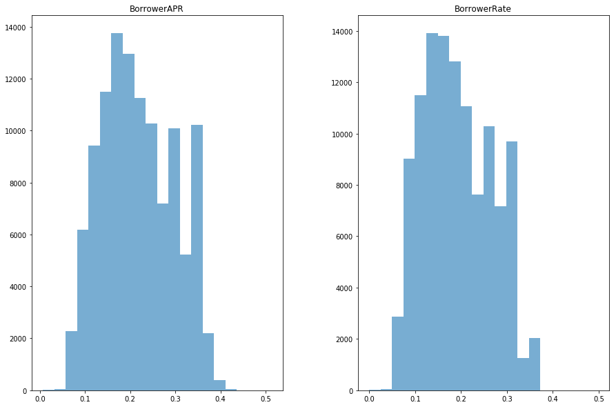

```python
# Plotting BorrowerRate and BorrowerAPR
data_loan[['BorrowerRate', 'BorrowerAPR']].hist(
    bins=20,
    figsize=(15, 10),
    grid = False,
    alpha=0.6
);
```

From the distribution, BorrowerAPR and BorrowerRate looks similar with a slight difference since the APR is always higher than the interest rate.

```python
# Counting the values in the loanStatus variable for a plot
data_loan['LoanStatus'].value_counts()
```

```
Current                   55730
Completed                 38061
Chargedoff                11992
Defaulted                  5018
Past Due (1-15 days)        800
Past Due (31-60 days)       361
Past Due (61-90 days)       311
Past Due (91-120 days)      304
Past Due (16-30 days)       265
FinalPaymentInProgress      203
Past Due (>120 days)         16
Cancelled                     5
Name: LoanStatus, dtype: int64
```

```python
# Setting the colour base for Visualizations
base_color = sb.color_palette()[0]
```

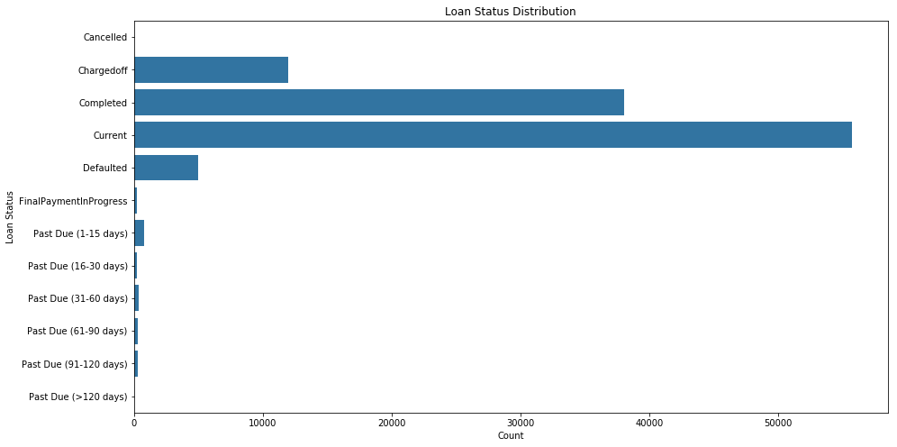

```python
# What is the distribution of Loan Status?
plt.figure(figsize=(15,8))
sb.countplot(data = data_loan, y = 'LoanStatus', color = base_color);
plt.title('Loan Status Distribution')
plt.xlabel('Count')
plt.ylabel('Loan Status');
```

From the distribution, the maximum number of loans are in 'current' status, followed by those with 'completed' and 'chargedoff' statsu.

```python
# What categories in employment are borrowers?
# Counting the values in the Employment Status variable for a plot
data_loan['EmploymentStatus'].value_counts()
```

```
Employed         66598
Full-time        26354
Self-employed     6052
Not available     5347
Other             3742
Part-time         1088
Not employed       835
Retired            795
Name: EmploymentStatus, dtype: int64
```

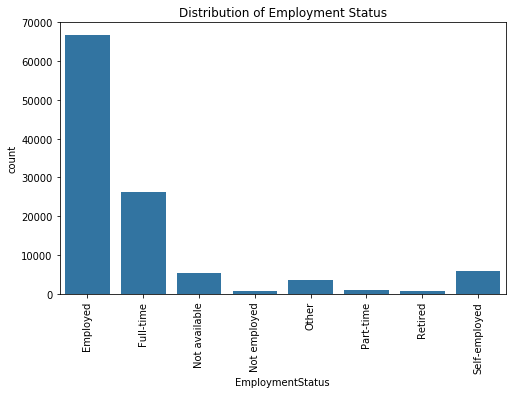

```python
# Plotting for EmploymentStatus
plt.figure(figsize=(8,5))
sb.countplot(data = data_loan, x = "EmploymentStatus", color = base_color);
plt.title('Distribution of Employment Status')
plt.xticks(rotation=90);
```

The plot shows that majority of the people are currently in employment while least have retired.

```python
# Counting the values in the occupation feature
data_loan['Occupation'].value_counts()
```

```
Other                                 28422
Professional                          13531
Computer Programmer                    4442
Executive                              4280
Teacher                                3729
Administrative Assistant               3677
Analyst                                3578
Sales - Commission                     3414
Accountant/CPA                         3209
Clerical                               3135
Sales - Retail                         2780
Skilled Labor                          2723
Retail Management                      2579
Nurse (RN)                             2475
Construction                           1777
Truck Driver                           1666
Laborer                                1578
Police Officer/Correction Officer      1561
Civil Service                          1445
Engineer - Mechanical                  1397
Military Enlisted                      1265
Food Service Management                1227
Engineer - Electrical                  1118
Food Service                           1115
Medical Technician                     1105
Attorney                               1033
Tradesman - Mechanic                    937
Social Worker                           733
Postal Service                          622
Professor                               556
                                      ...
Scientist                               367
Military Officer                        341
Bus Driver                              314
Principal                               307
Teacher's Aide                          275
Pharmacist                              255
Student - College Graduate Student      245
Landscaping                             234
Engineer - Chemical                     222
Investor                                213
Architect                               212
Pilot - Private/Commercial              198
Clergy                                  195
Student - College Senior                187
Car Dealer                              177
Chemist                                 144
Psychologist                            143
Biologist                               125
Religious                               124
Flight Attendant                        122
Tradesman - Carpenter                   119
Homemaker                               119
Student - College Junior                111
Tradesman - Plumber                     102
Student - College Sophomore              69
Dentist                                  67
Student - College Freshman               41
Student - Community College              28
Judge                                    22
Student - Technical School               16
Name: Occupation, Length: 67, dtype: int64
```

```python
#Checking for missing values in occupation feature
data_loan['Occupation'].isnull().sum()
```

```
3529
```

```python
data_loan['Occupation'].dropna()
```

```
0                           Other
1                    Professional
2                           Other
3                   Skilled Labor
4                       Executive
5                    Professional
6                  Sales - Retail
7                         Laborer
8                    Food Service
10                        Fireman
11                Waiter/Waitress
12                 Sales - Retail
13                   Construction
14            Computer Programmer
15                          Other
```

[output cut: 48 more lines]

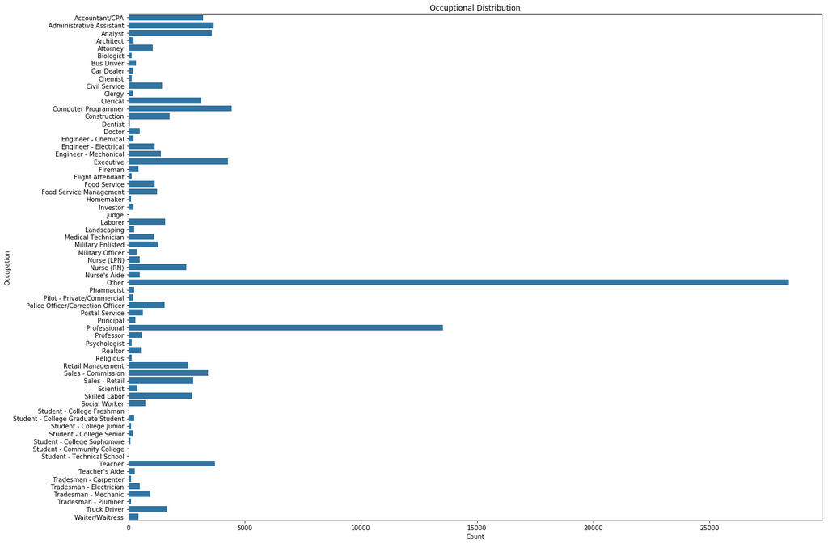

```python
# What category of worker top borrowers of Prosper?
# Plotting for occupation feature
plt.figure(figsize=(20,15))
sb.countplot(data = data_loan, y='Occupation', color = base_color);
plt.title('Occuptional Distribution')
plt.xlabel('Count')
plt.ylabel('Occupation');
```

From the distribution, it can be seen that the ‘Other’ and ‘Professional’ have the largest counts, but these two options does not provide us useful information for better analysis. Students are the least represented.

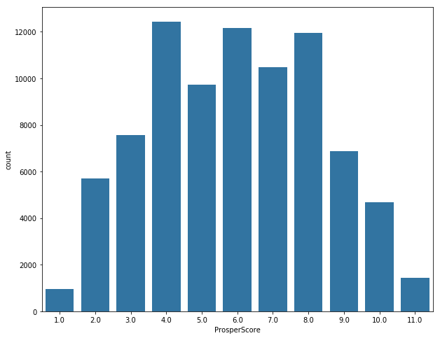

```python
# Plotting for Prosper Score
plt.figure(figsize=(10,8))
sb.countplot(data = data_loan, x ="ProsperScore", color = base_color);
#plt.xticks(rotation=90);
```

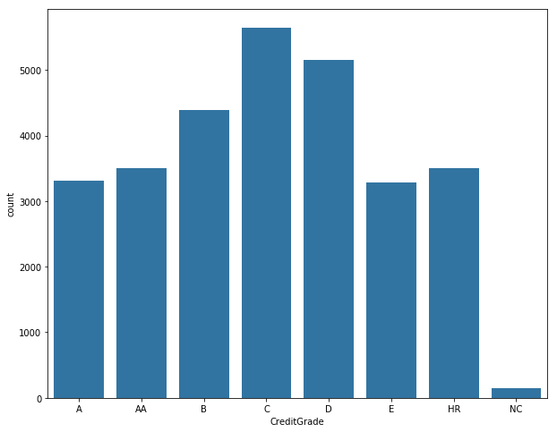

```python
# Plotting for CreditGrade
plt.figure(figsize=(10,8))
sb.countplot(data = data_loan, x ="CreditGrade", color = base_color);
#plt.xticks(rotation=90);
```

## Bivariate Exploration

> In this section, investigate relationships between pairs of variables in your data. Make sure the variables that you cover here have been introduced in some fashion in the previous section (univariate exploration).

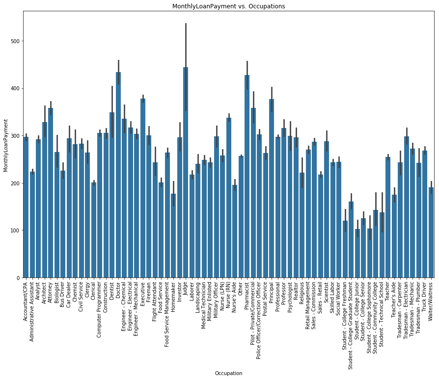

```python
# Which occupations have highest and lowerest monthly loan payment?
# MonthlyLoanPayment vs. Occupations
plt.figure(figsize=(15, 10))
sb.barplot(data =data_loan, x = 'Occupation', y='MonthlyLoanPayment',color = base_color )
plt.xlabel('Occupation')
plt.ylabel('MonthlyLoanPayment')
plt.title('MonthlyLoanPayment vs. Occupations')
plt.xticks(rotation=90)
plt.show();
```

The top 3 occupations with high monthly loan payment are Judges, Doctors and Pharmacists. The monthly loan payment however must positively correlate with the salary. The plot show consistent with salaries of each occupation. The groups that have lower monthly loan payment are students.

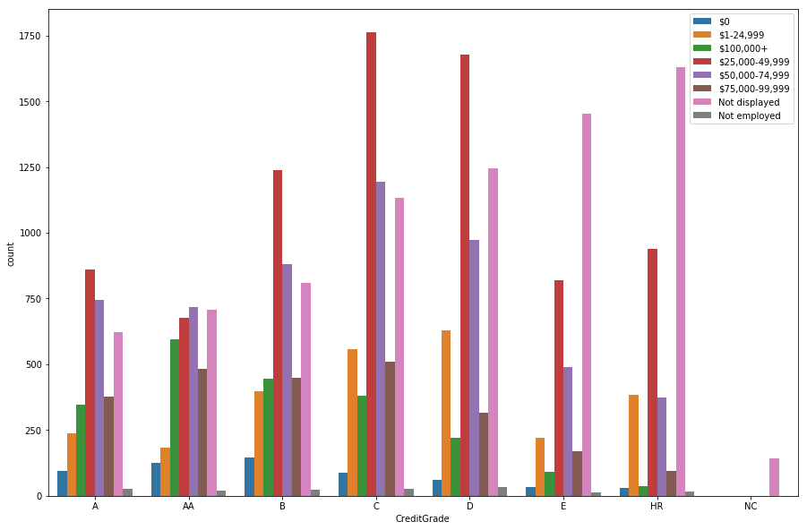

```python
# What is the relationship between Credit Grade and Income Range?
#colors = sb.color_palette('bright')
# Credit Grade vs. IncomeRage
plt.figure(figsize=(15, 10))
sb.countplot(data = data_loan, x = 'CreditGrade', hue= 'IncomeRange', )
plt.legend(loc = 1);
```

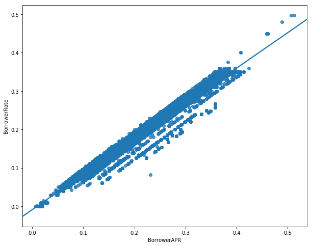

```python
# BorrowerAPR and BorrowerRate
plt.figure(figsize=(10, 8))
sb.regplot(data = data_loan, x = 'BorrowerAPR', y = 'BorrowerRate');
```

We can observe a positive correlation between BorrowerAPR and BorrowerRate from the figure above.

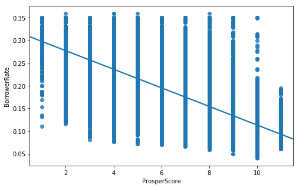

```python
#Prosper Rating vs. BorrowerRate
plt.figure(figsize=(8, 5))
sb.regplot(data=data_loan, x='ProsperScore', y= 'BorrowerRate');
```

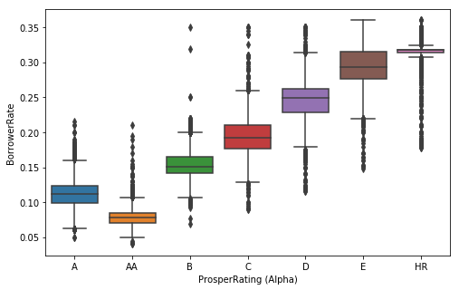

```python
#Prosper Rating vs. BorrowerRate
plt.figure(figsize=(8, 5))
sb.boxplot(data=data_loan, x='ProsperRating (Alpha)', y= 'BorrowerRate');
```

The figure show strong correlation between the prosper rating/score with the borrower’s rate. This relationship is however strong negative correlation between Prosper Rating and BorrowerRate.

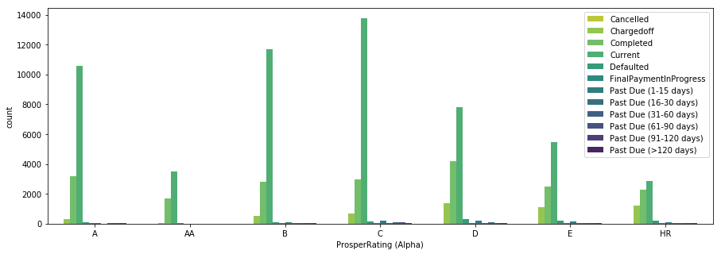

```python
#LoanStatus vs. ProsperRating
plt.figure(figsize=(15, 5))
sb.countplot(data = data_loan, x = 'ProsperRating (Alpha)', hue ='LoanStatus', palette = 'viridis_r')
#plt.xscale('log')
plt.legend(loc = 1);
```

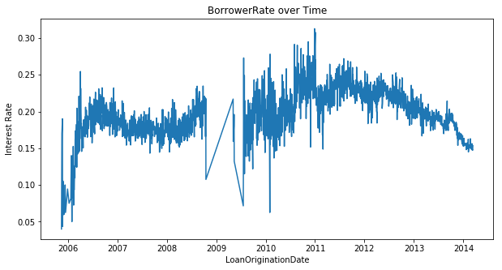

```python
#Converting datetime to year
data_loan['year'] = data_loan['LoanOriginationDate'].dt.year
#Plotting the BorrowerRate vs Time
plt.figure(figsize=(10, 5))
plt.plot(data_loan.groupby('LoanOriginationDate')['BorrowerRate'].mean());
plt.title('BorrowerRate over Time')
plt.ylabel('Interest Rate')
plt.xlabel('LoanOriginationDate');
```

The plot looks too noisy, therefore, I converted the 'LoanOriginationDate' to year to reduce the noise.

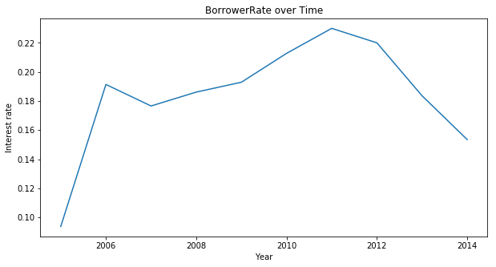

```python
plt.figure(figsize=(10, 5))
plt.plot(data_loan.groupby('year')['BorrowerRate'].mean());
plt.title('BorrowerRate over Time')
plt.ylabel('Interest Rate')
plt.xlabel('Year');
```

The plot now indicates how Borrower rates changed over time. However, there is no notable monotonic behaviors. Time effect may not be a better independent feature to predict a borrower’s interest rate.

```python
num_vars = ['ProsperScore', 'BorrowerRate', 'BorrowerAPR', 'DebtToIncomeRatio', 'StatedMonthlyIncome', 'LoanOriginalAmount', 'MonthlyLoanPayment', 'Term',
            'Investors','ListingCategory (numeric)']
```

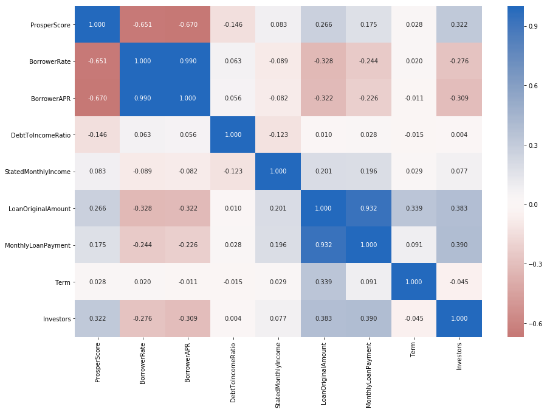

```python
# Plotting correlation Plot
plt.figure(figsize=(15, 10))
sb.heatmap(data_loan[num_vars].corr(), annot = True, fmt = '.3f', cmap = 'vlag_r', center = 0)
plt.show()
```

From the figure, we can be observed a strong postive association between BorrowerAPR and BorrowerRate. On the otherhand, ProsperScore has a strong negatively association BorrowerRate.

### Talk about some of the relationships you observed in this part of the investigation. How did the feature(s) of interest vary with other features in the dataset?

> ProsperRating and ProsperScore have a significant impact on BorrowerRate. BorrowerRate are negatively correlated with ProsperRating. There is also a strong postive relationship between BorrowerAPR and BorrowerRate. The BorrowerAPR is the annual cost of a loan to a borrower. Unlike an interest rate, it includes other charges or fees (such as mortgage insurance, most closing costs, discount points and loan origination fees) to reflect the total cost of the loan.

### Did you observe any interesting relationships between the other features (not the main feature(s) of interest)?

> Observing the Borrower rates over time, there is no notable monotonic behaviors. Hence, Time effect may not be a better independent feature to predict a borrower’s interest rate.

## Multivariate Exploration

> In this part of the project, I created plots of three or more variables to investigate my data further.

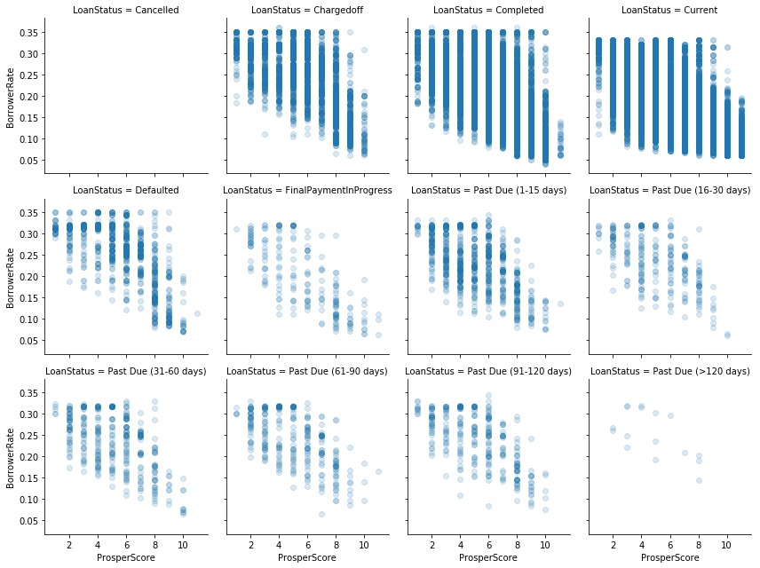

```python
# multivariate plot of BorrowerRate by ProsperScore and LoanStatus
g = sb.FacetGrid(data=data_loan, col='LoanStatus', col_wrap=4);
g.map(plt.scatter, 'ProsperScore', 'BorrowerRate', alpha=1/6);
```

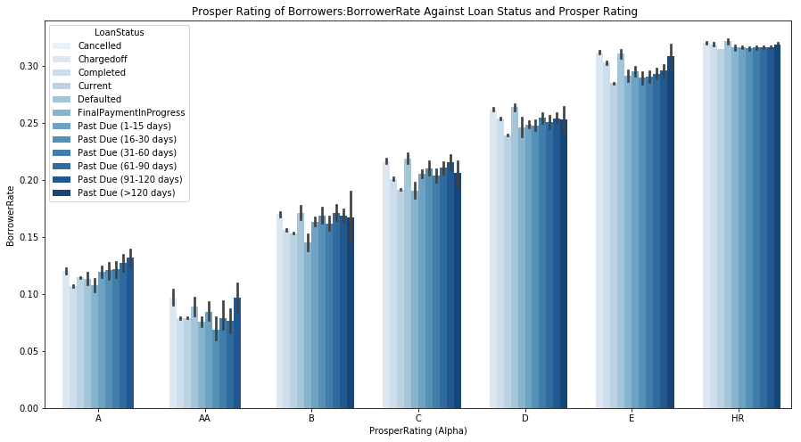

```python
#multivariate plot of ProsperRating by Borrower Rate and Loan Status
plt.figure(figsize = (15, 8))
sb.barplot(data = data_loan, x = 'ProsperRating (Alpha)', y = 'BorrowerRate', hue = 'LoanStatus', palette="Blues")
plt.xlabel('ProsperRating (Alpha)')
plt.ylabel('BorrowerRate')
plt.title('Prosper Rating of Borrowers:BorrowerRate Against Loan Status and Prosper Rating  ')
plt.show();
```

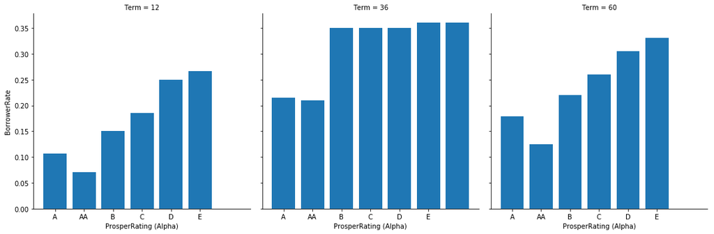

```python
# plt.figure(figsize = (15, 8))
g=sb.FacetGrid(data = data_loan, col='Term', col_wrap=3, size=5)
g.map(plt.bar,'ProsperRating (Alpha)', 'BorrowerRate');
```

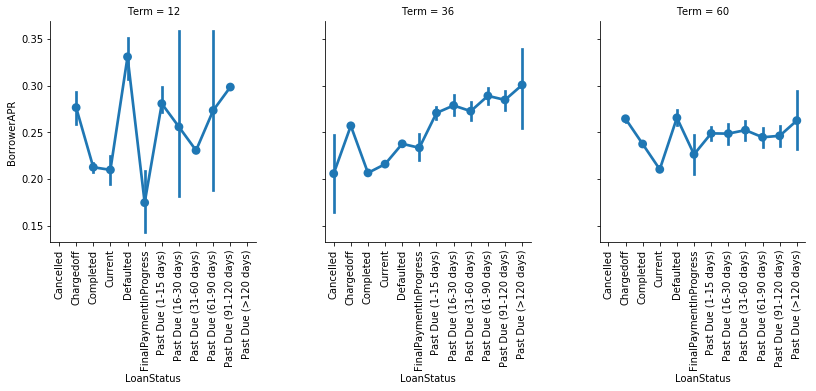

```python
g=sb.FacetGrid(data = data_loan, col='Term', col_wrap=3, size= 4)
g.map(sb.pointplot, 'LoanStatus', 'BorrowerAPR', order = None,);
g.set_xticklabels(rotation=90)
```